# speaker diarization test

this is a speaker diarization test using a pretrained speaker verification model (resemblyzer based on SV2TTS model) and spectral clustering, UMAP + HDBSCAN clustering.

we use resemblyzer to create d-vectors from overlapping windows (model is fixed(?) size of 1.6 seconds, we can adjust overlap with parameter below controlling frames per second).

we then optionally apply UMAP dimensionality reduction on the vectors, and cluster with spectral clustering, HDBSCAN, K-Means or Gaussian Mixture Model. for this test, we allow the models to know the expected speakers.

we visualize the cluster labels, and choose Bayesian GMM.

we modify the `resemblyzer` code to skip the VAD trimming, to maintain the original audio length and thus the original audio's timestamps. this audio has relatively low background noise but the prolonged silences may introduce some noisiness to the clusters. so ideally, we would apply the model to the trimmed audio then adjust the results to account for the silences so that the predictions align with the input transcript.

## test video:

https://www.youtube.com/watch?v=7i_cUvrnreo

## tools

test file audio, text downloaded with:

- https://downsub.com
- https://ontiva.com/youtube-to-wav-converter/

## references

- https://medium.com/saarthi-ai/who-spoke-when-build-your-own-speaker-diarization-module-from-scratch-e7d725ee279
- https://github.com/resemble-ai/Resemblyzer
- https://umap-learn.readthedocs.io/en/latest/clustering.html
- https://stackoverflow.com/questions/48269092/hdbscan-python-choose-number-of-clusters

```python
import datetime
import hdbscan
import IPython.display as ipd
import numpy as np
import time
import umap

from collections import Counter
from scipy.cluster.hierarchy import fcluster
from scipy.io.wavfile import read as read_wav
from sklearn.cluster import KMeans
from sklearn.mixture import BayesianGaussianMixture, GaussianMixture
from tools import preprocess_wav
from resemblyzer import VoiceEncoder
from spectralcluster import SpectralClusterer
```

```python
# only for plotting
%matplotlib inline
from matplotlib import pyplot as plt
```

```python
# dummy logger for notebooks
from tools import Logger
logging = Logger("diarize")
logging.setLevel("DEBUG")
logging.debug("this is a test")
```

```
[2021-05-17T23:29:51.901519] diarize -    DEBUG: this is a test
```

## test files

```python
audio_file = "./data/kbs_test.16khz.wav"
transcript_file = "./data/kbs_test.srt"
known_speakers = 6
windows_per_second = 4  # controls overlap of windows. window is fixed(?) at 1.6s
```

## format transcript

format srt from `https://downsub.com` into tab-separated data

```
# input

1
00:00:00,089 --> 00:00:04,470
자 그럼 감독님 배우분들과 함께 올해 청춘에 대해서 이야기를 나눠보도록

# output

0.089    4.47    자 그럼 감독님 배우분들과 함께 올해 청춘에 대해서 이야기를 나눠보도록
```

```python
def stamp2seconds(stamp):
    """convert srt duration timestamp to seconds elapsed"""
    timestamp = datetime.datetime.strptime(stamp, "%H:%M:%S,%f")
    delta = datetime.timedelta(hours=timestamp.hour,
                               minutes=timestamp.minute,
                               seconds=timestamp.second,
                               microseconds=timestamp.microsecond)
    return delta.total_seconds()
```

```python
def srt_to_transcript(file_path):
    """convert srt file to list of (time start, time end, text) segments"""
    with open(transcript_file) as f:
        data = f.read().split("\n\n")[:-1]

    segments = []

    for line in data:
        idx, timestamps, text = line.split("\n")
        time_start, time_end = timestamps.split(" --> ")
        segments.append( (stamp2seconds(time_start), stamp2seconds(time_end), str(text.strip()) ) )

    return segments
```

```python
transcript = srt_to_transcript(transcript_file)
```

## diarize audio file using d-vectors and clustering

```python
def get_most_common(lst):
    """get most frequent item in list"""
    data = Counter(lst)
    return max(lst, key=data.get)
```

```python
def diarize_by_window(audio, sr, known_speakers=-1, windows_per_second=4,
                      cluster_mode="bayesgmm", umap_components=2, hdbscan_min_samples=8,
                      hdbscan_min_cluster_size=32, device="cpu", random_state=42):

    if cluster_mode not in ("hdbscan", "bayesgmm", "kmeans", "spectral"):
        raise ValueError('cluster_mode must be in "hdbscan", "bayesgmm", "kmeans", "spectral"!')

    logging.debug("preprocessing audio of shape {} with device {}...".format(audio.shape, device))
    if audio.dtype == np.dtype('int16'):
        audio = audio.astype(np.float32, order='C') / 32768.0
    audio, mask = preprocess_wav(audio)

    # get vectors
    logging.debug("embedding preprocessed audio in shape {}...".format(audio.shape))
    encoder = VoiceEncoder(device, verbose=False)
    _, windowed_embeds, wav_slices = encoder.embed_utterance(audio, return_partials=True, rate=windows_per_second)
    wav_segments = [(slc.start/sr, slc.stop/sr) for slc in wav_slices]

    # cluster
    logging.debug("got embeddings of shape {}".format(windowed_embeds.shape))

    # spectral clustering, the original implementation
    if cluster_mode == "spectral":
        logging.debug("clustering with spectral clustering...")
        if known_speakers < 2:
            known_speakers = 2
        clusterer = SpectralClusterer(
            min_clusters=known_speakers,
            max_clusters=100,
            p_percentile=0.90,
            gaussian_blur_sigma=1)
        labels = clusterer.predict(windowed_embeds)

    # UMAP and other clustering, as suggested for word embeddings
    else:
        logging.debug("dimensionality reduction with UMAP...")
        projection = umap.UMAP(n_components=umap_components,
                               random_state=random_state,
                               metric='cosine').fit_transform(windowed_embeds)

        if cluster_mode == "bayesgmm":
            logging.debug("clustering with Bayesian Gaussian Mixture Model...")
            bgmm = BayesianGaussianMixture(n_components=6, random_state=random_state).fit(projection)
            labels = bgmm.predict(projection)

        elif cluster_mode == "kmeans":
            logging.debug("clustering with K-Means...")
            kmns = KMeans(n_clusters=6, random_state=random_state).fit(projection)
            kmn_labels = kmns.predict(projection)

        elif cluster_mode == "hdbscan":
            if known_speakers > 1:
                logging.debug("clustering with HDBSCAN & fixing cluster count...")
                clusterer = hdbscan.HDBSCAN(
                    min_samples=hdbscan_min_samples,
                    min_cluster_size=hdbscan_min_cluster_size,
                ).fit(projection)
                fix_clustering = clusterer.single_linkage_tree_.to_numpy()
                labels = fcluster(fix_clustering, known_speakers, criterion='maxclust')
            else:
                logging.debug("clustering with HDBSCAN...")
                labels = hdbscan.HDBSCAN(
                    min_samples=hdbscan_min_samples,
                    min_cluster_size=hdbscan_min_cluster_size,
                ).fit_transform(projection)

    logging.debug("done with {} labels".format(labels.shape))

    return audio, windowed_embeds, wav_segments, labels
```

```python
# librosa is slow for some reason so load with scipy and convert if needed
logging.debug("loading file {}".format(audio_file))
sr, audio = read_wav(audio_file)
dur = time.strftime('%H:%M:%S', time.gmtime(audio.shape[0]/sr))
logging.debug("loaded file of duration {}".format(dur))
```

```
[2021-05-17T23:29:51.940072] diarize -    DEBUG: loading file ./data/kbs_test.16khz.wav
[2021-05-17T23:29:51.948787] diarize -    DEBUG: loaded file of duration 00:17:17
```

```python
proc_audio, embeddings, wav_segments, labels = diarize_by_window(audio, sr,
                                                                 known_speakers=known_speakers,
                                                                 windows_per_second=windows_per_second,
                                                                 cluster_mode="bayesgmm",
                                                                 device="cpu")
```

```
[2021-05-17T23:29:51.952210] diarize -    DEBUG: preprocessing audio of shape (16592896,) with device cpu...
[2021-05-17T23:29:53.861923] diarize -    DEBUG: embedding preprocessed audio in shape (16592896,)...
[2021-05-17T23:30:08.940358] diarize -    DEBUG: got embeddings of shape (4143, 256)
[2021-05-17T23:30:08.940458] diarize -    DEBUG: dimensionality reduction with UMAP...
[2021-05-17T23:30:23.960397] diarize -    DEBUG: clustering with Bayesian Gaussian Mixture Model...
[2021-05-17T23:30:24.004597] diarize -    DEBUG: done with (4143,) labels
```

```python
len(wav_segments), len(labels)
```

```
(4143, 4143)
```

## visualize and benchmark clustering methods

```python
plt.rcParams['figure.figsize'] = [9, 6]
plt.rcParams['figure.dpi'] = 100
```

### reduce with UMAP

```python
%%time
projection = umap.UMAP(n_neighbors=16,
                       min_dist=0.1,
                       random_state=42,
                       n_components=2,
                       metric='cosine').fit_transform(embeddings)
```

```
CPU times: user 9.14 s, sys: 402 ms, total: 9.54 s
Wall time: 5.88 s
```

## spectral clustering

cluster on original embeddings, plot on projection

```python
%%time
spectral_clusterer = SpectralClusterer(
    min_clusters=known_speakers,
    max_clusters=100,
    p_percentile=0.90,
    gaussian_blur_sigma=1)
spec_labels = spectral_clusterer.predict(embeddings)
```

```
CPU times: user 3min 30s, sys: 2.94 s, total: 3min 33s
Wall time: 32.3 s
```

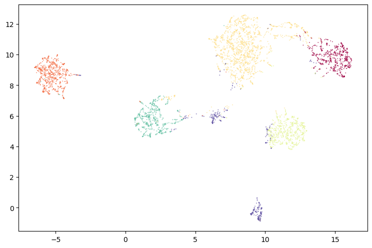

```python
plt.scatter(projection[:, 0],
            projection[:, 1],
            c=spec_labels,
            s=0.1,
            cmap='Spectral');
```

## Bayesian Guassian Mixture Model

cluster on UMAP projections

```python
%%time
bgmm = BayesianGaussianMixture(n_components=known_speakers, random_state=42).fit(projection)
bgm_labels = bgmm.predict(projection)
```

```
CPU times: user 846 ms, sys: 3.61 ms, total: 850 ms
Wall time: 106 ms
```

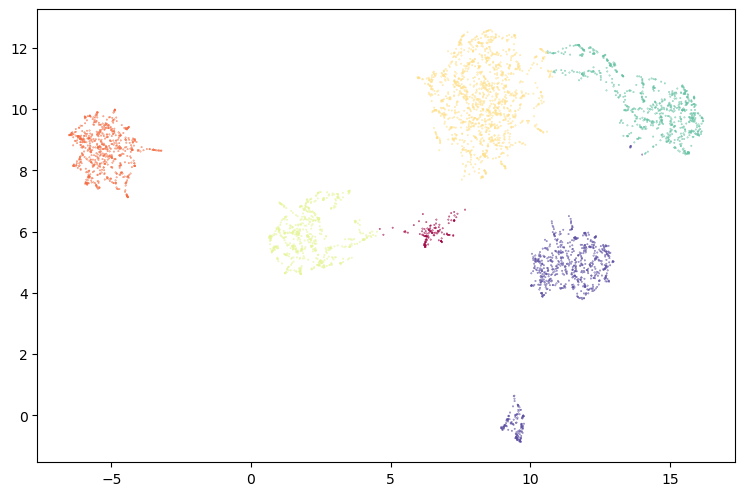

```python
plt.scatter(projection[:, 0],
            projection[:, 1],
            c=bgm_labels,
            s=0.1,
            cmap='Spectral')
```

## HDBSCAN

cluster on UMAP projections.

optionally fix cluster size

```python
%%time
hdb_labels = hdbscan.HDBSCAN(
    min_samples=8,
    min_cluster_size=32,
).fit_predict(projection)
```

```
CPU times: user 433 ms, sys: 11.9 ms, total: 445 ms
Wall time: 55.7 ms
```

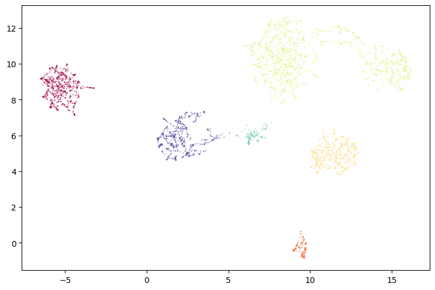

```python
plt.scatter(projection[:, 0],
            projection[:, 1],
            c=hdb_labels,
            s=0.1,
            cmap='Spectral')
```

```python
%%time
clusterer = hdbscan.HDBSCAN(
    min_samples=8,
    min_cluster_size=32,
).fit(projection)
fix_clustering = clusterer.single_linkage_tree_.to_numpy()
hdbfixed_labels = fcluster(fix_clustering, known_speakers, criterion='maxclust')
```

```
CPU times: user 63.4 ms, sys: 95 µs, total: 63.5 ms
Wall time: 63 ms
```

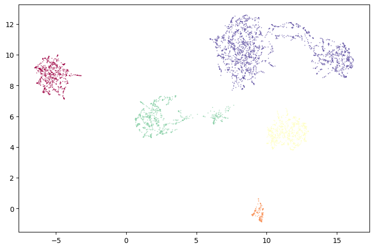

```python
plt.scatter(projection[:, 0],
            projection[:, 1],
            c=hdbfixed_labels,
            s=0.1,
            cmap='Spectral')
```

## K-Means

cluster on UMAP projections

```python
%%time
kmns = KMeans(n_clusters=known_speakers, random_state=42).fit(projection)
kmn_labels = kmns.predict(projection)
```

```
CPU times: user 335 ms, sys: 8.21 ms, total: 344 ms
Wall time: 46.7 ms
```

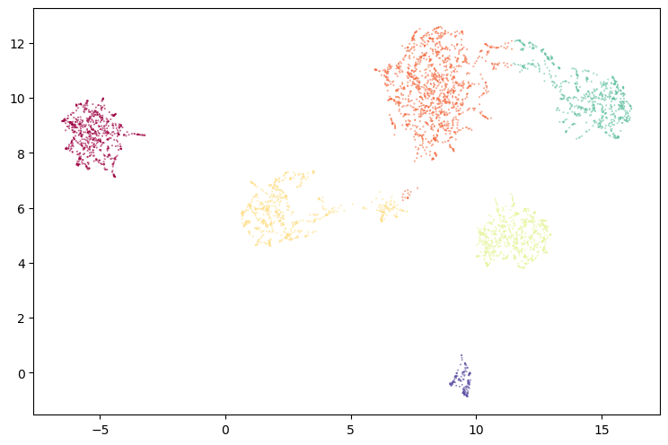

```python
plt.scatter(projection[:, 0],
            projection[:, 1],
            c=kmn_labels,
            s=0.1,
            cmap='Spectral')
```

## label speaker by segment

for each segment, get labels of all windows that fall mostly within that segment boundary.

then assign a label according to the most frequent label from that span.

because the google stt does not segment different speakers' speech well, some lines contain more than one speaker.

this can be seen in the "low confidence" segments (where confidence is most frequent label's percentage of all labels in segment span)

```python
def diarize_by_segment(transcript_tuples, wav_segments, labels, win_duration=1.6):

    segment_labels = []
    segment_scores = []

    default_label = get_most_common(labels)

    for t_s, t_d, txt in transcript:
        # get all labels within the time window
        candidates = []
        for i in range(len(wav_segments)):
            # if more than half falls after the segment, ignore and break
            if wav_segments[i][0] + win_duration/2 > t_d:
                break
            # if more than half the window extends beyond that start, count it
            if wav_segments[i][0] + win_duration/2 > t_s:
                candidates.append(labels[i])
        # segment_label
        if len(candidates) > 0:
            segment_label = get_most_common(candidates)
            segment_confidence = candidates.count(segment_label)/len(candidates)
        # if no labels for this segment, falback to majority
        else:
            segment_label = default_label
            segment_confidence = 0.0

        segment_labels.append(segment_label)
        segment_scores.append(segment_confidence)

    # for prettification, reorder by order of appearance
    ordered_segments = []
    for seg in segment_labels:
        if seg not in ordered_segments:
            ordered_segments.append(seg)
        if len(ordered_segments) == len(set(segment_labels)):
            break
    segment_labels = [ordered_segments.index(l) for l in segment_labels]

    return [(t[0], t[1], segment_scores[i], segment_labels[i], t[2]) for i, t in enumerate(transcript_tuples)]
```

```python
diarized_transcripts = diarize_by_segment(transcript, wav_segments, labels)
```

## format the output

source: https://www.youtube.com/watch?v=7i_cUvrnreo

```python
last_speaker = -1
for t_s, t_d, conf, spkr, txt in diarized_transcripts:
    tss = time.strftime('%H:%M:%S', time.gmtime(t_s))[:9]
    tds = time.strftime('%H:%M:%S', time.gmtime(t_d))[:9]
    if spkr != last_speaker:
        print("")
    print("{:>9} ~ {:>9} conf {:>5.1f}% speaker{:02}: {}".format(tss, tds, conf*100, spkr, txt))
    last_speaker = spkr
```

```
 00:00:00 ~  00:00:04 conf 100.0% speaker00: 자 그럼 감독님 배우분들과 함께 올해 청춘에 대해서 이야기를 나눠보도록
 00:00:04 ~  00:00:09 conf 100.0% speaker00: 할게요 오늘 진행된 인터뷰는 드라마와 관련된 내용 위주로 진행을 하도록
 00:00:09 ~  00:00:15 conf 100.0% speaker00: 하겠습니다 먼저 연출을 맡은 숭 민혁 감독 부터 인사 말씀과 또 작품에
 00:00:15 ~  00:00:16 conf 100.0% speaker00: 대한 간단한 소개
 00:00:16 ~  00:00:21 conf 100.0% speaker00: 그리고 배우 분들은 갑자 맡으신 역할 소개한 말씀이 책 부탁드릴께요

 00:00:21 ~  00:00:23 conf  88.9% speaker01: 감독님

 00:00:24 ~  00:00:29 conf  94.7% speaker02: 4 안녕하세요 오월애 성취 4 연출을 맡은 성빈 옆 입니다
 00:00:29 ~  00:00:35 conf 100.0% speaker02: 올해 청춘 은 1980년 을 배경으로 한 레트로 청춘 멜로 드라마 안되요
 00:00:35 ~  00:00:36 conf 100.0% speaker02: [음악]
 00:00:36 ~  00:00:41 conf 100.0% speaker02: 일단은 이 80 년 이라는 시대적 배경이 랑 광주 라는 특정한 공간적
 00:00:41 ~  00:00:48 conf 100.0% speaker02: 배경 그리고 그 당시에 이제 젊은이들이 사랑하고 미워하고 슬퍼하고 이런
 00:00:48 ~  00:00:51 conf 100.0% speaker02: 보편적 인간 들의 이야기를 담은 드라마 라고 생각을 합니다
 00:00:51 ~  00:00:55 conf 100.0% speaker02: 특정한 사건이 주된 내용은 아니구요
 00:00:55 ~  00:00:59 conf 100.0% speaker02: 그 사이에 살아갔던 평범한 사람들의 이야기로 생각을 하고 재미있게
 00:00:59 ~  00:01:01 conf  75.0% speaker02: 봐주셨으면 감사하겠습니다

 00:01:01 ~  00:01:05 conf 100.0% speaker00: 저희 번에는 뉴스 원의 김민지 기자 캐서 어 이도현 씨와 고민 cc 두
 00:01:05 ~  00:01:07 conf 100.0% speaker00: 분께 질문 주셨는데요
 00:01:07 ~  00:01:13 conf 100.0% speaker00: 이번 드라마로 음 지상파 에서 첫 주연을 맡았는데요 느낌이 남다를 것
 00:01:13 ~  00:01:16 conf  53.8% speaker00: 같습니까 어떠신지요

 00:01:20 ~  00:01:28 conf 100.0% speaker03: 느낌만이 남다르죠 에 굉장히 떨리고 4 일단 너무 몇 뭐 저는 배우를
 00:01:28 ~  00:01:32 conf 100.0% speaker03: 하시는 분들이라면 꿈 이라고 생각을 하는게 하나가 있는데 그게 이제 이
 00:01:32 ~  00:01:36 conf 100.0% speaker03: kbs 위에 이따 마케 푸석 걸려있어요
 00:01:36 ~  00:01:40 conf 100.0% speaker03: 저는 언젠간 나도 적의 4 포스터가 관리기 가지 라는 생각을 하면서 접
 00:01:40 ~  00:01:43 conf 100.0% speaker03: 처지에 있는 적 보스 터인데 4
 00:01:43 ~  00:01:47 conf  88.9% speaker03: 회상 장면에서 별관 그대의 여기에 흑인 이제하 해 줘 이제 에 또 그걸
 00:01:47 ~  00:01:52 conf 100.0% speaker03: 또 저희 보니까 찍어서 보내 주셨더라구요 아아 시다가 아들 은 또 잘됐다
 00:01:52 ~  00:01:57 conf 100.0% speaker03: 이러시면서 그 저도 그게 꿈이 어 썼는데 왜 그걸 어쨌든 지금 현재로서는
 00:01:57 ~  00:02:00 conf 100.0% speaker03: 감사하게도 이룬 상태에서
 00:02:00 ~  00:02:04 conf 100.0% speaker03: 그래서 그걸 보면서 아 정말 더 열심히 준비해야겠다
 00:02:04 ~  00:02:09 conf 100.0% speaker03: 어쨌든 그만큼 책임감도 많이 부여가 됐고 그래서 더 이제 열심히 파고
 00:02:09 ~  00:02:12 conf 100.0% speaker03: 파고 이야기도 많이 나누고 작품에 대해서 그런 식으로 준비를 하고
 00:02:12 ~  00:02:14 conf  75.0% speaker03: 다가갔던 것입니다

 00:02:14 ~  00:02:18 conf 100.0% speaker00: 어져 2 뭐 제작발표회를 하면서 많이 여쭤 보긴 했는데 또 그 건물
 00:02:18 ~  00:02:21 conf 100.0% speaker00: 외벽에 포스터 붙은게 뿌듯하고 자랑스러웠다
 00:02:21 ~  00:02:26 conf 100.0% speaker00: 이게 답변 또 굉장히 신선한 에 어떤 새롭고 내 그럴 수도 있겠어요 진짜
```

[output cut: 217 more lines]

```
 00:16:22 ~  00:16:30 conf  93.3% speaker03: oil 오렐 허 10 밤 9시 30분 kbs 2tv 에서 이 의대생 희
 00:16:30 ~  00:16:36 conf 100.0% speaker03: 태 와 간호사 명의 여파 수차 어차 한다는 그 수련을 만나보세요
 00:16:36 ~  00:16:39 conf 100.0% speaker03: 초 정말 재밌을 거에요 뭐
 00:16:39 ~  00:16:43 conf 100.0% speaker03: 안방에서 리모콘을 들고 쉬운 치운 쇼핑 하세요
 00:16:43 ~  00:16:45 conf 100.0% speaker03: 어

 00:16:45 ~  00:16:50 conf  75.0% speaker00: 단 좋습니다 그럼 서울 표현을 달했다 일도 1 주셨구요
 00:16:50 ~  00:16:54 conf 100.0% speaker00: 자 이것으로 kbs 2tv 새 월화드라마 오 5월의 청춘 온 나의
 00:16:54 ~  00:16:57 conf 100.0% speaker00: 제작발표회를 모두 마치도록 하겠습니다
 00:16:57 ~  00:17:01 conf 100.0% speaker00: 시청해 주신 여러분들께 대단히 감사드리구요 여러분께 우리 손 인사 한번
 00:17:01 ~  00:17:03 conf 100.0% speaker00: 하면서 인사 드릴까요
 00:17:03 ~  00:17:06 conf  56.2% speaker00: 네 감사합니다 아 아 아 아 아 4:30
 00:17:06 ~  00:17:11 conf  88.2% speaker00: 4 5 5 월 3 의 오늘 밤 9시 30분 오월애 청춘 많은 관심
 00:17:11 ~  00:17:14 conf 100.0% speaker00: 부탁드리구요 지금까지 전에 진행을 맡은 아나운서 이재성 이었읍니다
 00:17:14 ~  00:17:16 conf  55.6% speaker00: 감사합니다
```